# R Course BL4005

## General linear models

You will recall that there are actually different patterns going on here for Grazed versus Ungrazed treatments:

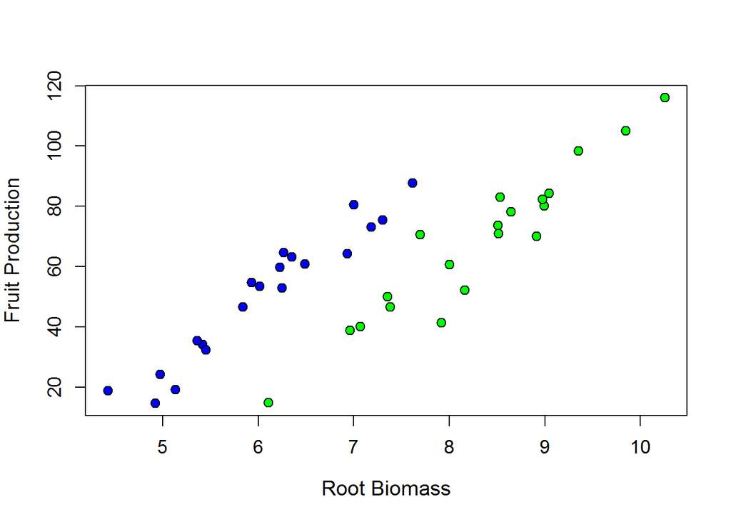

In this case, we might want to test for the effets of BOTH *Root* and *Grazing* in the same model. This is called a general linear model, and one can include multiple explanatory variables, which can be continuous or categorical.

This also couldn’t be simpler in R:

```r
# We simply include both Root and Grazing as separate terms on the right-hand side of the ~ in the lm() function, seperated by a + sign:
gen.lin.model<- lm(Fruit ~ Root + Grazing, data=comp.data)

# We just stored the results in a new object called gen.lin.model, now let's see a summary of the actual results:
summary(gen.lin.model)
```

```
##
## Call:
## lm(formula = Fruit ~ Root + Grazing, data = comp.data)
##
## Residuals:
##      Min       1Q   Median       3Q      Max
## -17.1920  -2.8224   0.3223   3.9144  17.3290
##
## Coefficients:
##                 Estimate Std. Error t value Pr(>|t|)
## (Intercept)     -127.829      9.664  -13.23 1.35e-15 ***
## Root              23.560      1.149   20.51  < 2e-16 ***
## GrazingUngrazed   36.103      3.357   10.75 6.11e-13 ***
## ---
## Signif. codes:  0 '***' 0.001 '**' 0.01 '*' 0.05 '.' 0.1 ' ' 1
##
## Residual standard error: 6.747 on 37 degrees of freedom
## Multiple R-squared:  0.9291, Adjusted R-squared:  0.9252
## F-statistic: 242.3 on 2 and 37 DF,  p-value: < 2.2e-16
```

```r
# Or you can see the output as an ANOVA table:
anova(gen.lin.model)
```

```
## Analysis of Variance Table
##
## Response: Fruit
##           Df  Sum Sq Mean Sq F value    Pr(>F)
## Root       1 16795.0 16795.0  368.91 < 2.2e-16 ***
## Grazing    1  5264.4  5264.4  115.63 6.107e-13 ***
## Residuals 37  1684.5    45.5
## ---
## Signif. codes:  0 '***' 0.001 '**' 0.01 '*' 0.05 '.' 0.1 ' ' 1
```

So both *Root* and *Grazing* are highly significant. What about an interaction - i.e. is the linear effect of Root Biomass on Fruit Production different in Grazed versus Ungrazed treatments?

```r
# To test for an interaction between Root and Grazing, we simply specify the model like this, using the * symbol between the terms, which stands for "please kindly test for an interaction there R, like a good lad"
gen.lin.model2<- lm(Fruit ~ Root * Grazing, data=comp.data)

# We just stored the results in a new object called gen.lin.2, now let's see a summary of the actual results:
summary(gen.lin.model2)
```

```
##
## Call:
## lm(formula = Fruit ~ Root * Grazing, data = comp.data)
##
## Residuals:
##      Min       1Q   Median       3Q      Max
## -17.3177  -2.8320   0.1247   3.8511  17.1313
##
## Coefficients:
##                      Estimate Std. Error t value Pr(>|t|)
## (Intercept)          -125.173     12.811  -9.771 1.15e-11 ***
## Root                   23.240      1.531  15.182  < 2e-16 ***
## GrazingUngrazed        30.806     16.842   1.829   0.0757 .
## Root:GrazingUngrazed    0.756      2.354   0.321   0.7500
## ---
## Signif. codes:  0 '***' 0.001 '**' 0.01 '*' 0.05 '.' 0.1 ' ' 1
##
## Residual standard error: 6.831 on 36 degrees of freedom
## Multiple R-squared:  0.9293, Adjusted R-squared:  0.9234
## F-statistic: 157.6 on 3 and 36 DF,  p-value: < 2.2e-16
```

```r
# Or you can see the output as an ANOVA table:
anova(gen.lin.model2)
```

```
## Analysis of Variance Table
##
## Response: Fruit
##              Df  Sum Sq Mean Sq  F value    Pr(>F)
## Root          1 16795.0 16795.0 359.9681 < 2.2e-16 ***
## Grazing       1  5264.4  5264.4 112.8316 1.209e-12 ***
## Root:Grazing  1     4.8     4.8   0.1031      0.75
## Residuals    36  1679.6    46.7
## ---
## Signif. codes:  0 '***' 0.001 '**' 0.01 '*' 0.05 '.' 0.1 ' ' 1
```

So it turns out that there is no interaction here, that is, the effect of Root Biomass on Fruit Production is the same in both treatments.

We can show that graphically by plotting seperate lines through the data points for each treatment level:

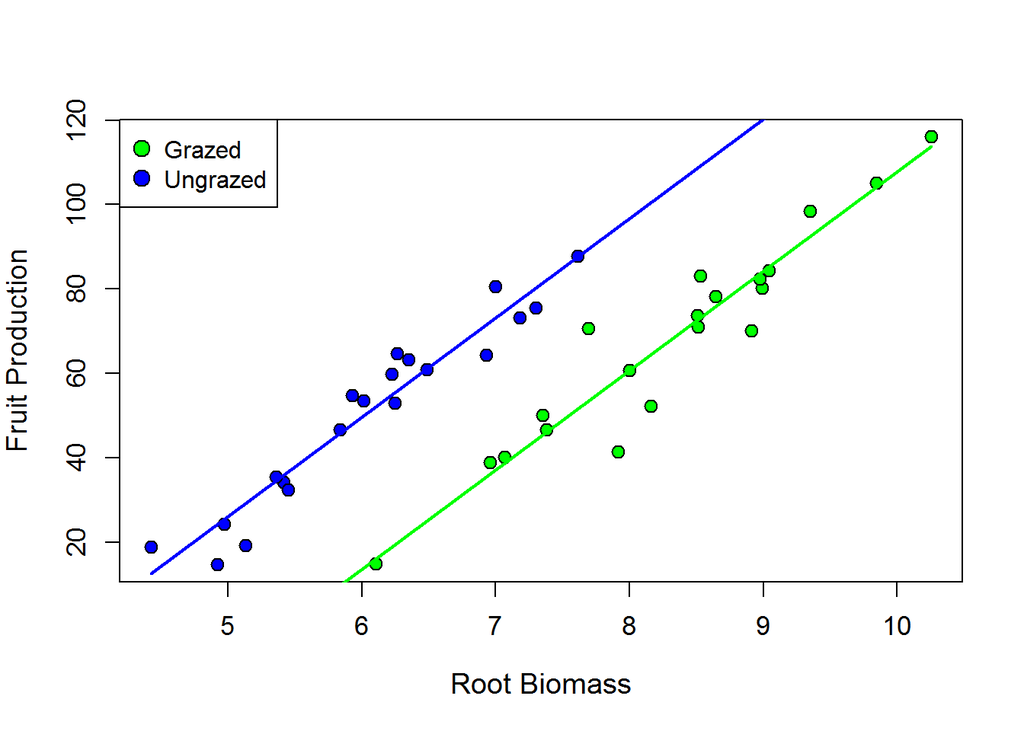

```r
culr<- ifelse(comp.data$Grazing == "Grazed", "green", "blue")

plot(Fruit ~ Root, data=comp.data,
     xlab="Root Biomass",
     ylab="Fruit Production",
     cex.lab=1.2,
     cex.axis=1.1,
     cex= 1.2,
     pch=21,
     bg=culr)

legend("topleft", legend = c("Grazed", "Ungrazed"),
       pch=21, pt.bg = c("Green", "Blue"), pt.cex=1.5)

xv<- seq(min(comp.data$Root), max(comp.data$Root), length.out=2)
GR<- coef(gen.lin.model)[1] + coef(gen.lin.model)[2]*xv
UGR<- coef(gen.lin.model)[1] + coef(gen.lin.model)[2]*xv + coef(gen.lin.model)[3]

lines(xv, GR, col="green", lwd=2)
lines(xv, UGR, col="blue", lwd=2)
```

# That’s all folks, remember, practice practice practice with R, it’s the only way!!!